# Get started with igoR

Diego Hernangómez

This vignette introduces the main data sets and functions in **igoR** through visual examples.

The examples build on analyses from Pevehouse et al. (2020). For more information about the IGO data sets and additional downloads, see [Intergovernmental Organizations (version 3)](https://correlatesofwar.org/data-sets/IGOs/).

*The original dyad-year data set is not included because of its size (about 500 MB in Stata `.dta` format). The `igo_dyadic()` function derives comparable joint membership results from the included data.*

## Definitions

From Pevehouse et al. (2019):

### What is an IGO?

> The original data set defines an intergovernmental organization (IGO) using the following criteria:
> 1. An IGO must consist of at least three members of the [Correlates of War state system](https://correlatesofwar.org/data-sets/cow-country-codes/).
> 2. An IGO must hold regular plenary sessions at least once every ten years.
> 3. An IGO must possess a permanent secretariat and corresponding headquarters.

### When does an IGO begin?

> The data set begins coding an IGO in the first year the organization functions. In some cases, individual members are recorded by year of accession or signature.

### When does an IGO cease to exist?

> Version 3.0 of the IGO data set uses the following criteria:
> - An organization is considered terminated when its description includes one of the following terms: `replaced`, `succeeded`, `superseded`, `integrated`, `merged` or `dies`.

## Analysis

This section reproduces selected analyses based on figures in Pevehouse et al. (2020).

### Initial setup

```r
library(igoR)

# Load helper packages.
library(ggplot2)
library(dplyr)
```

First, create a custom `ggplot2::theme()` object named `theme_igor`. All figures in this vignette use this theme.

```r
theme_igor <- theme(
  axis.title = element_blank(),
  axis.line.x.bottom = element_line("black"),
  axis.line.y.left = element_line("black"),
  axis.text = element_text(color = "black", family = "sans"),
  axis.text.y.left = element_text(angle = 90, hjust = 0.5),
  legend.position = "bottom",
  legend.title = element_blank(),
  legend.key = element_blank(),
  legend.key.width = unit(2, "cm"),
  legend.text = element_text(family = "sans", size = 11.5),
  legend.box.background = element_rect(color = "black", linewidth = 1),
  legend.spacing = unit(1.2 / 100, "npc"),
  plot.background = element_rect("grey90"),
  plot.margin = unit(rep(0.5, 4), "cm"),
  panel.background = element_rect("white"),
  panel.grid = element_blank(),
  panel.border = element_rect(fill = NA, colour = "grey90"),
  panel.grid.major.y = element_line("grey90")
)
```

### IGOs overview

The following code counts IGOs and states in the Correlates of War (COW) system by year. The data cover 1816 to 2014.

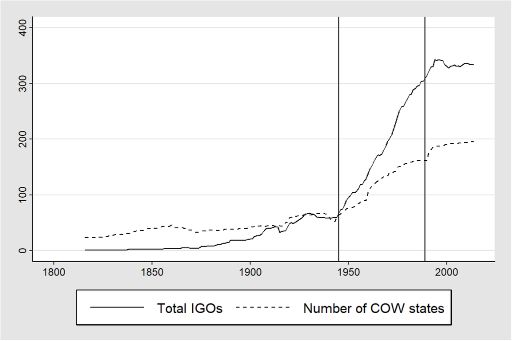

Figure 1: IGOs and COW states in the state system, 1816-2014

```r
# Summarize values by year.
igos_by_year <- igo_year_format3 %>%
  group_by(year) %>%
  summarise(value = n(), .groups = "keep") %>%
  mutate(variable = "Total IGOs")

countries_by_year <- state_year_format3 %>%
  group_by(year) %>%
  summarise(value = n(), .groups = "keep") %>%
  mutate(variable = "Number of COW states")

all_by_year <- igos_by_year %>%
  bind_rows(countries_by_year) %>%
  # Label the plot.
  mutate(
    variable = factor(
      variable,
      levels = c("Total IGOs", "Number of COW states")
    )
  )

# Plot the results.
ggplot(all_by_year, aes(x = year, y = value)) +
  geom_line(color = "black", aes(linetype = variable)) +
  scale_x_continuous(limits = c(1800, 2014)) +
  scale_linetype_manual(values = c("solid", "dashed")) +
  geom_vline(xintercept = c(1945, 1989)) +
  ylim(0, 400) +
  theme_igor
```

### IGO starts and endings

This plot shows how many IGOs started or ended in each year.

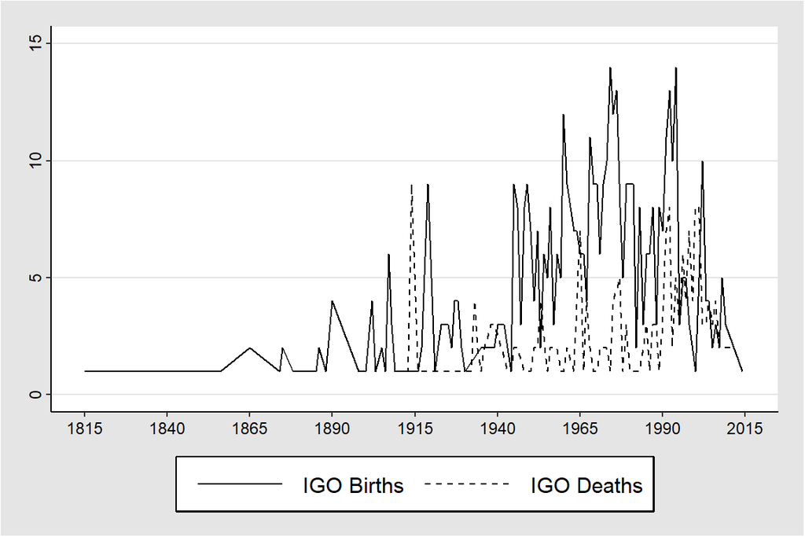

Figure 2: IGO starts and endings, 1816-2014

```r
# Summarize IGO starts and endings by year.

df <- igo_search()

births <- df %>%
  mutate(year = sdate) %>%
  group_by(year) %>%
  summarise(value = n(), .groups = "keep") %>%
  mutate(variable = "IGO Births")

deads <- df %>%
  mutate(year = deaddate) %>%
  group_by(year) %>%
  summarise(value = n(), .groups = "keep") %>%
  mutate(variable = "IGO Deaths")

births_and_deads <- births %>%
  bind_rows(deads) %>%
  filter(!is.na(year))

# Plot the results.
ggplot(births_and_deads, aes(x = year, y = value)) +
  geom_line(color = "black", aes(linetype = variable)) +
  scale_linetype_manual(values = c("solid", "dashed")) +
  scale_x_continuous(
    limits = c(1815, 2015),
    breaks = seq(1815, 2015, by = 25)
  ) +
  ylim(0, 15) +
  theme_igor
```

### IGOs across regions

This plot shows the number of IGOs by region. The region definitions are based on Pevehouse et al. (2020) and the complementary replication data set (PRIO 2020).

**IGOs across regions: codes**

```r
# Cross-regional and universal codes are not included.

asia <- c(
  550,
  560,
  570,
  580,
  590,
  600,
  610,
  640,
  650,
  660,
  670,
  725,
  750,
  825,
  1030,
  1345,
  1400,
  1530,
  1532,
  2300,
  2770,
  3185,
  3330,
  3560,
  3930,
  4115,
  4150,
  4160,
  4170,
  4190,
  4200,
  4220,
  4265,
  4440
)

middle_east <- c(
  370,
  380,
  390,
  400,
  410,
  420,
  430,
  440,
  450,
  460,
  470,
  490,
  500,
  510,
  520,
  1110,
  1410,
  1990,
  2000,
  2220,
  3450,
  3800,
  4140,
  4270,
  4380
)

europe <- c(
  20,
  300,
  780,
  800,
  832,
  840,
  860,
  1020,
  1050,
  1070,
  1080,
  1125,
  1140,
  1390,
  1420,
  1440,
  1563,
  1565,
  1580,
  1585,
  1590,
  1600,
  1610,
  1620,
  1630,
  1640,
  1645,
  1653,
  1660,
  1670,
  1675,
  1680,
  1690,
  1700,
  1710,
  1715,
  1720,
  1730,
  1740,
  1750,
  1760,
  1770,
  1780,
  1790,
  1800,
  1810,
  1820,
  1830,
  1930,
  1970,
  1980,
  2310,
  2325,
  2345,
  2440,
  2450,
  2550,
  2575,
  2610,
  2650,
  2705,
  2890,
  2972,
  3010,
  3095,
  3230,
  3290,
  3360,
  3485,
  3505,
  3585,
  3590,
  3600,
  3610,
  3620,
  3630,
  3640,
  3650,
  3655,
  3660,
  3665,
  3762,
  3810,
  3855,
  3860,
  3910,
  4000,
  4350,
  4450,
  4460,
  4510,
  4520,
  4540
)

africa <- c(
  30,
  40,
  50,
  60,
  80,
  90,
  100,
  110,
  115,
  120,
  125,
  130,
  140,
  150,
  155,
  160,
  170,
  180,
  190,
  200,
  210,
  225,
  240,
  250,
  260,
  280,
  290,
  690,
  700,
  710,
  940,
  1060,
  1150,
  1170,
  1260,
  1290,
  1310,
  1320,
  1330,
  1340,
  1355,
  1430,
  1450,
  1460,
  1470,
  1475,
  1480,
  1500,
  1510,
  1520,
  1870,
  2080,
  2090,
  2230,
  2330,
  2795,
  3300,
  3310,
  3470,
  3480,
  3510,
  3520,
  3570,
  3740,
  3760,
  3761,
  3790,
  3820,
  3875,
  3905,
  3970,
  4010,
  4030,
  4050,
  4055,
  4080,
  4110,
  4120,
  4130,
  4230,
  4240,
  4250,
  4251,
  4340,
  4365,
  4480,
  4485,
  4490,
  4500,
  4501,
  4503
)

americas <- c(
  310,
  320,
  330,
  340,
  720,
  760,
  815,
  875,
  880,
  890,
  900,
  910,
  912,
  913,
  920,
  950,
  970,
  980,
  990,
  1000,
  1010,
  1095,
  1130,
  1486,
  1489,
  1490,
  1860,
  1890,
  1920,
  1950,
  2070,
  2110,
  2120,
  2130,
  2140,
  2150,
  2160,
  2170,
  2175,
  2180,
  2190,
  2200,
  2203,
  2206,
  2210,
  2260,
  2340,
  2490,
  2560,
  2980,
  3060,
  3340,
  3370,
  3380,
  3390,
  3400,
  3410,
  3420,
  3428,
  3430,
  3670,
  3680,
  3812,
  3830,
  3880,
  3890,
  3900,
  3925,
  3980,
  4070,
  4100,
  4260,
  4280,
  4370
)
```

```r
# `africa`, `americas`, `asia`, `europe` and `middle_east` were created in the
# previous chunk, which is collapsed for readability.

regions <- igo_search() %>%
  mutate(
    region = case_when(
      ionum %in% africa ~ "Africa",
      ionum %in% americas ~ "Americas",
      ionum %in% asia ~ "Asia",
      ionum %in% europe ~ "Europe",
      ionum %in% middle_east ~ "Middle East",
      TRUE ~ NA
    )
  ) %>%
  select(ioname, region)
```

The next step joins the region classifications to the IGO-year data and counts IGOs by region.

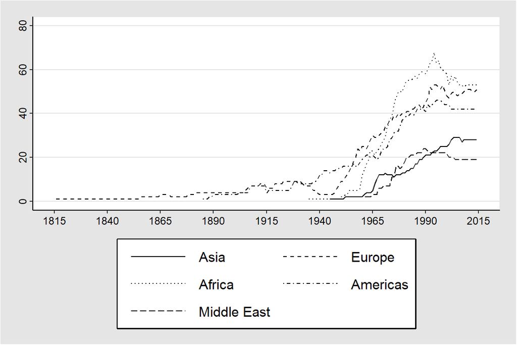

Figure 3: IGO counts across regions, 1816-2014

```r
# The `regions` data set was created in the previous chunk.

# Select all IGOs.
alligos <- igo_year_format3 %>%
  select(ioname, year)

regionsum <- alligos %>%
  left_join(regions) %>%
  group_by(year, region) %>%
  summarise(value = n(), .groups = "keep") %>%
  filter(!is.na(region)) %>%
  # Prepare for plotting.
  mutate(
    region = factor(
      region,
      levels = c(
        "Asia",
        "Europe",
        "Africa",
        "Americas",
        "Middle East"
      )
    )
  )

# Plot the results.
ggplot(regionsum, aes(x = year, y = value)) +
  geom_line(color = "black", aes(linetype = region)) +
  scale_linetype_manual(
    values = c("solid", "dashed", "dotted", "dotdash", "longdash")
  ) +
  guides(linetype = guide_legend(ncol = 2, byrow = TRUE)) +
  ylim(0, 80) +
  scale_x_continuous(
    limits = c(1815, 2015),
    breaks = seq(1815, 2015, by = 25)
  ) +
  theme_igor
```

### Selected states in Asia

This plot shows the number of full IGO memberships for five states in Asia: India, China, Pakistan, Indonesia and Bangladesh.

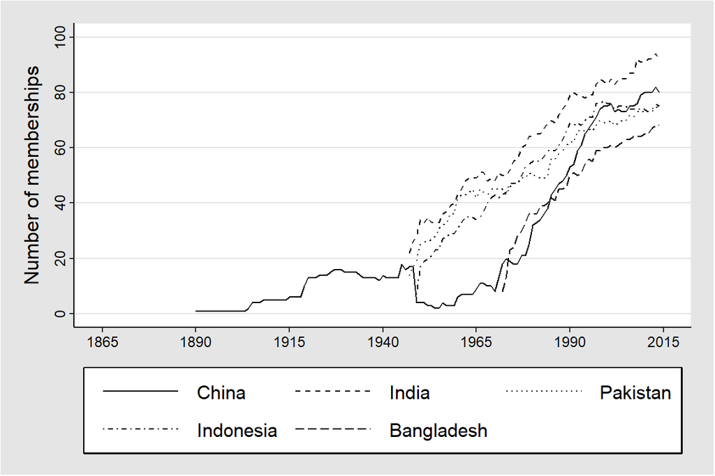

Figure 4: IGO membership: five states in Asia, 1865-2014

```r
asia5_cntries <- c("China", "India", "Pakistan", "Indonesia", "Bangladesh")

# Use five states in Asia.
asia5_igos <- igo_state_membership(
  state = asia5_cntries,
  year = 1865:2014,
  status = "Full Membership"
)

asia5 <- asia5_igos %>%
  group_by(statenme, year) %>%
  summarise(values = n(), .groups = "keep") %>%
  mutate(statenme = factor(statenme, levels = asia5_cntries))

# Plot the results.
ggplot(asia5, aes(x = year, y = values)) +
  geom_line(color = "black", aes(linetype = statenme)) +
  scale_linetype_manual(
    values = c("solid", "dashed", "dotted", "dotdash", "longdash")
  ) +
  guides(linetype = guide_legend(ncol = 3, byrow = TRUE)) +
  theme(
    axis.title.y.left = element_text(
      family = "sans",
      size = 12,
      margin = margin(r = 6)
    )
  ) +
  scale_x_continuous(
    limits = c(1865, 2015),
    breaks = seq(1865, 2015, by = 25)
  ) +
  scale_y_continuous(
    "Number of memberships",
    breaks = seq(0, 100, 20),
    limits = c(0, 100)
  ) +
  theme_igor
```

### Joint memberships

The final plot counts full joint memberships in dyad-year data for Spain and four selected states.

[figure not shown]

Figure 5: Number of IGOs with full joint memberships with Spain (selected states), 1816-2014

```r
selected_countries <- c("France", "Morocco", "China", "USA")

spain_selected <- igo_dyadic("Spain", selected_countries)

# Compute the number of full joint memberships.
spain_selected <- spain_selected %>%
  rowwise() %>%
  mutate(values = sum(c_across(aaaid:wassen) == 1))

# Plot the results.
ggplot(spain_selected, aes(x = year, y = values)) +
  geom_line(color = "black", aes(linetype = statenme2)) +
  scale_linetype_manual(values = c("solid", "dashed", "dotted", "dotdash")) +
  guides(linetype = guide_legend(ncol = 2, byrow = TRUE)) +
  theme(
    axis.title.y.left = element_text(
      family = "sans",
      size = 10,
      margin = margin(r = 6)
    )
  ) +
  scale_x_continuous(
    limits = c(1815, 2015),
    breaks = seq(1815, 2015, by = 25)
  ) +
  scale_y_continuous(
    "Number of memberships",
    breaks = seq(0, 110, 20),
    limits = c(0, 110)
  ) +
  theme_igor +
  geom_vline(xintercept = 1939, alpha = 0.2) +
  annotate("label", x = 1938, y = 60, size = 3, label = "Spanish \nCivil War") +
  geom_vline(xintercept = 1978, alpha = 0.2) +
  annotate(
    "label",
    x = 1970,
    y = 100,
    size = 3,
    label = "Constitution \nof Spain"
  )
```

## References

Pevehouse, Jon C. W., Timothy Nordstrom, Roseanne W. McManus, and Anne Spencer Jamison. 2020. “Tracking Organizations in the World: The Correlates of War IGO Version 3.0 Datasets.” *Journal of Peace Research* 57 (3): 492–503. https://doi.org/10.1177/0022343319881175.

Pevehouse, Jon, Roseanne McManus, and Timothy Nordstrom. 2019. *Codebook for Correlates of War 3 International Governmental Organizations Data Set Version 3.0*.https://correlatesofwar.org/wp-content/uploads/IGO-Codebook_v3_short-copy.pdf .

PRIO. 2020. *Replication Datasets: Journal of Peace Research*. Peace Research Institute Oslo; Online. https://www.prio.org/journals/jpr/replicationdata.